iPheGWAS module is developed to bring intelligence into PheGWAS by incorporating a new heuristic approach developed by our team to order traits based on its genetic correlation quickly and efficiently. As a result, the iPheGWAS module is integrated seamlessly into the PheGWAS module. We also improved the previous PheGWAS codebase for faster landscape visualization.

This package is packaged with datasets used in PheGWAS and some datasets to demonstrate iPheGWAS. If you are looking for the entire data used for studies 1 and 2 in iPheGWAS, please download it from [here](https://drive.google.com/drive/folders/1975iMOimOQ1GyzxpIBYLG41tXnBOG03y?usp=sharing). Checkout the individual datasets [here](https://drive.google.com/drive/folders/1_tCKT8yOtMsjkc_O8G0AQoEFA2HqX-gp?usp=sharing).

Here are the datasets that are available from iPheGWAS study2 within the package.

```r
library(iphegwas)
```

To run PheGWAS, pass the dataframe names available in your environment to fastprocessphegwas as vector of dataframe names.

Before passing the dataframe makes sure your preprocess your GWAS summarystats dataframe to have columns named in this way.

```
CHR     BP       rsid A1 A2    beta     se P.value gene
```

```r
head(ibd, 3)
```

```
#>    CHR     BP       rsid A1 A2    beta     se P.value
#> 1:   1 721290 rs12565286  c  g  0.0949 0.0408 0.02005
#> 2:   1 752566  rs3094315  a  g -0.0399 0.0193 0.03921
#> 3:   1 752721  rs3131972  a  g  0.0388 0.0194 0.04564
```

```r
head(bmi, 3)
```

```
#>    CHR        BP       rsid A1 A2    beta     se P.value
#> 1:  12 126890980  rs1000000  G  A  0.0001 0.0044 0.98190
#> 2:   4  21618674 rs10000010  T  C -0.0029 0.0030 0.33740
#> 3:   4   1357325 rs10000012  G  C -0.0095 0.0054 0.07853
```

```r
head(Wasisthipratio, 3)
```

```
#>    CHR       BP      rsid A1 A2  beta     se P.value
#> 1:  10 94471975 rs2497311  T  C 0.023 0.0059   1e-04
#> 2:  15 70765255 rs7178130  A  G 0.017 0.0044   1e-04
#> 3:   2 66615915 rs7603236  C  T 0.016 0.0042   1e-04
```

```r
head(CrohnsDisease, 3)
```

```
#>    CHR     BP      rsid A1 A2    beta     se P.value
#> 1:   1 752566 rs3094315  a  g -0.0558 0.0253 0.02774
#> 2:   1 752721 rs3131972  a  g  0.0549 0.0255 0.03149
#> 3:   1 754182 rs3131969  a  g  0.0343 0.0268 0.19940
```

```r
head(UlcerativeColitis, 3)
```

```
#>    CHR     BP       rsid A1 A2    beta     se P.value
#> 1:   1 721290 rs12565286  c  g  0.0575 0.0483  0.2336
#> 2:   1 752566  rs3094315  a  g -0.0299 0.0241  0.2156
#> 3:   1 752721  rs3131972  a  g  0.0321 0.0242  0.1861
```

```r
## Bringing all package data to the environment
ibd <- ibd
bmi <- bmi
Wasisthipratio <- Wasisthipratio
CrohnsDisease <- CrohnsDisease
UlcerativeColitis <- UlcerativeColitis
```

The gene column is optional. There is an option to map genes to rsid if you want this, please set `genemap = TRUE` (By default it is set to `FALSE`). If `TRUE` it will take some time as it is using Gene BioMart Module to map genes internally.

```r
phenos <- c("ibd", "bmi", "CrohnsDisease", "UlcerativeColitis", "Wasisthipratio")
yy <- fastprocessphegwas(phenos)
```

Once the processing is done, pass the dataframe that you got from `fastprocessphegwas` to `landscapefast` to see the landscape; Here, the landscape orders in the order that we are passing the `phenos`.

```r
print(phenos)
```

```
#> [1] "ibd"               "bmi"               "CrohnsDisease"     "UlcerativeColitis"
#> [5] "Wasisthipratio"
```

```r
landscapefast(yy, sliceval = 7, phenos = phenos)
```

```
#> [1] "Processing for the entire chromosome"
```

If you want to order the traits in the landscape based on the genetic correlation, then you pass the order what you get from the iphegwas module.

```r
landscapefast(yy, sliceval = 7, phenos = iphegwas(phenos))
```

```
#> [1] "Processing for the entire chromosome"
```

You can also run the iPheGWAS module independently to examine the dendrograms.

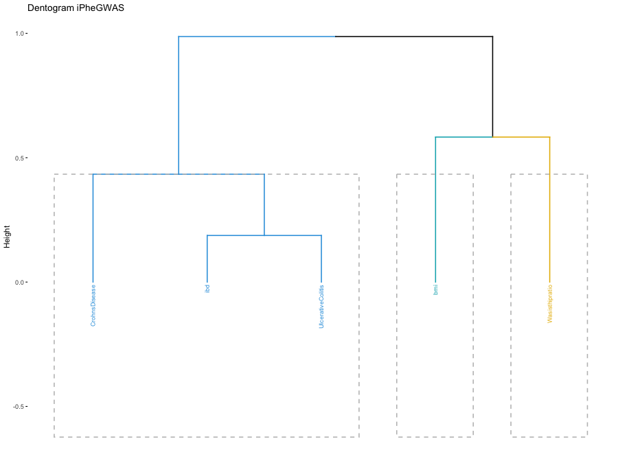

```r
iphegwas(phenos, dentogram = TRUE)
```

We also have an LDSC module to calculate; (We use LDSC python modules https://github.com/bulik/ldsc for this - thanks to LDSC team)

- Ordered traits based on the LDSC
- Genetic correlation plot
- Dendrogram based on LDSC
- You also get a `correlationmatrix` in your global environment that you can use later. If `correlationmatrix` exist in your global environment then `ldscmod` won't recalculate the rg, but you can use `ldscmod` with `dentogram = TRUE` and `plot = TRUE`.

You need to pass the `pathname` and `ldscpath`. The path name is the absolute path to the folder containing the summary statistics for which you want to find the genetic correlation. You must have the summary statistics in this folder, or else you will get an error. All the additional files that ldsc generates will also be put into the location `pathname` for later reference if you are interested in looking at those files for additional information that LDSC provides.

```r
pathname <- system.file("extdata", "samplesummary", package = "iphegwas")
ldscpath <- system.file("extdata", "ldsc", package = "iphegwas")
```

If you want to order the traits in the landscape based on the genetic correlation, then you pass the order what you get from the ldsc module.

```r
landscapefast(yy, sliceval = 7, phenos = ldscmod(pathname, ldscpath))
```

```
#> [1] "Processing for the entire chromosome"
```

You can also run the ldsc module independently to examine the dendrograms (using LDSC).

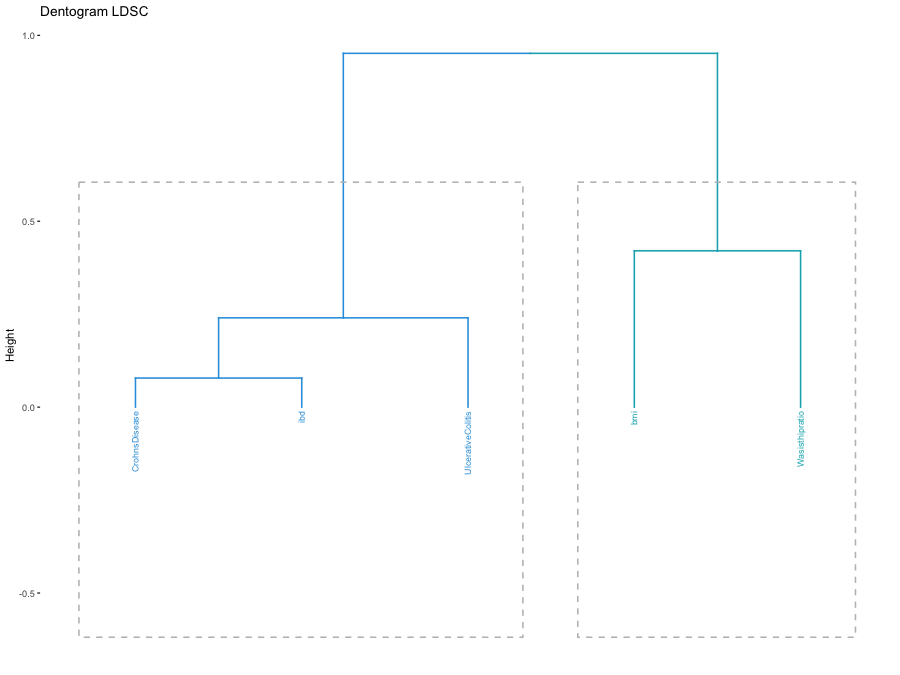

```r
ldscmod(pathname, ldscpath, dentogram = TRUE)
```

You can also run the ldsc module independently to get the genetic correlation plot (using LDSC).

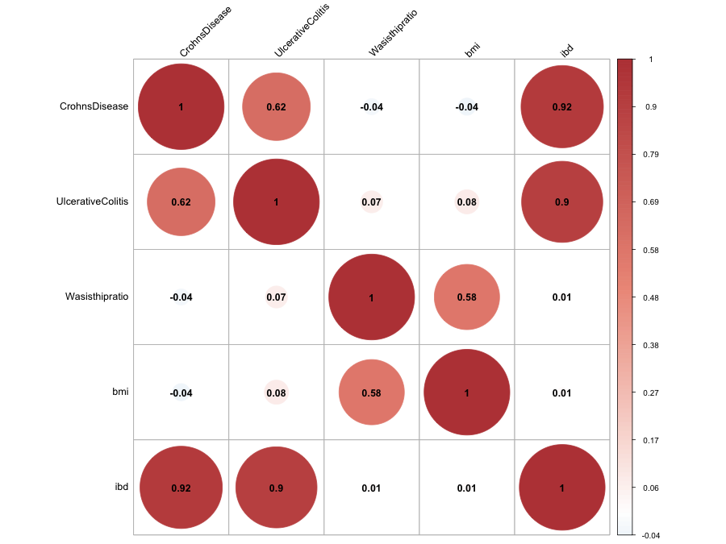

```r
ldscmod(pathname, ldscpath, plot = TRUE)
```

In addition to the heuristic approach that we developed, all the functionalities outlined in the *PheGWAS* are also available in *iphegwas* package. Considering performance in mind, the entire codebase is rewritten, and you will notice that the iphegwas package is faster than the PheGWAS package. Adding here the code from the PheGWAS vignette.

Following processed summary data are from the lipid consortium:

```r
head(hdl, 3)
```

```
#>   CHR        BP       rsid A1 A2   beta     se P.value
#> 1   7  92383888       rs10  c  a 0.0051 0.0142  0.7646
#> 2  12 126890980  rs1000000  g  a 0.0073 0.0057  0.3375
#> 3   4  21618674 rs10000010  t  c 0.0049 0.0034  0.2546
#>                                                            gene
#> 1                                                          CDK6
#> 2 RP4-809F18.1;RP4-809F18.2;RP5-944M2.1;RP5-944M2.2;RP5-944M2.3
#> 3                            KCNIP4;RP11-556G22.1;RP11-556G22.3
```

```r
head(ldl, 3)
```

```
#>   CHR        BP       rsid A1 A2   beta     se P.value
#> 1   7  92383888       rs10  a  c 0.0317 0.0151 0.03411
#> 2  12 126890980  rs1000000  a  g 0.0050 0.0062 0.51210
#> 3   4  21618674 rs10000010  t  c 0.0058 0.0036 0.13150
#>                                                            gene
#> 1                                                          CDK6
#> 2 RP4-809F18.1;RP4-809F18.2;RP5-944M2.1;RP5-944M2.2;RP5-944M2.3
#> 3                            KCNIP4;RP11-556G22.1;RP11-556G22.3
```

```r
head(trig, 3)
```

```
#>   CHR        BP       rsid A1 A2   beta     se P.value
#> 1   7  92383888       rs10  a  c 0.0163 0.0137 0.39990
#> 2  12 126890980  rs1000000  a  g 0.0114 0.0056 0.08781
#> 3   4  21618674 rs10000010  t  c 0.0032 0.0033 0.26940
#>                                                            gene
#> 1                                                          CDK6
#> 2 RP4-809F18.1;RP4-809F18.2;RP5-944M2.1;RP5-944M2.2;RP5-944M2.3
#> 3                            KCNIP4;RP11-556G22.1;RP11-556G22.3
```

```r
head(tchol, 3)
```

```
#>   CHR        BP       rsid A1 A2   beta     se P.value
#> 1   7  92383888       rs10  a  c 0.0310 0.0148 0.03129
#> 2  12 126890980  rs1000000  a  g 0.0014 0.0061 0.99050
#> 3   4  21618674 rs10000010  t  c 0.0095 0.0035 0.01953
#>                                                            gene
#> 1                                                          CDK6
#> 2 RP4-809F18.1;RP4-809F18.2;RP5-944M2.1;RP5-944M2.2;RP5-944M2.3
#> 3                            KCNIP4;RP11-556G22.1;RP11-556G22.3
```

```r
## I am changing the name of the dataframe to something meaningful, as the name of the
## dataframe will be used as phenotype names in the landscape. This also bring all package
## data to the environment.
HDL <- hdl
LDL <- ldl
TRIGS <- trig
TOTALCHOLESTROL <- tchol
```

```r
phenos <- c("HDL", "LDL", "TRIGS", "TOTALCHOLESTROL")
y <- fastprocessphegwas(phenos)
```

```r
landscapefast(y, sliceval = 10, phenos = phenos)
```

```
#> [1] "Processing for the entire chromosome"
```

```r
landscapefast(y, sliceval = 7.5, chromosome = 19, phenos = phenos)
```

```
#> [1] "Processing for chromosome 19"
```

```r
landscapefast(y, sliceval = 7.5, chromosome = 19, geneview = TRUE, phenos = phenos)
```

```
#> [1] "Processing for chromosome 19"
#> [1] "GENE View is active"
```

3D visualization with LD block (for european population) passing externally, parameter to pass LD and also calculate the mutualLD block

```r
landscapefast(y, sliceval = 30, chromosome = 19, calculateLD = TRUE, mutualLD = TRUE, phenos = phenos)
```

```
#> [1] "Processing for chromosome 19"
#> [1] "Calculating the mutually shared SNP's"
```